# Piotr Bajger - Etap 2.

Piotr Bajger

4 czerwca 2017

# 2. Diagnostyka i wizualizacja modelu

W Etapie 1. skonstruowaliśmy dwa modele liniowe na podstawie przygotowanego pliku z danymi **qTimeFinal**:

- model1: Pozycji w teście oraz ID zadania.
- model2: ID zadania zagnieżdżonego w pozycji w teście.

W tym etapie dokonam wyboru jednego z tych modeli, zwizualizuję dane oraz wyniki modelu.

## 2.1 Wizualizacja danych

Poniżej przeprowadzimy wizualizację danych w celu lepszego zrozumienia ich struktury.

Sprawdźmy, czy średni czas rozwiązania zadań różni się od ich pozycji w kwestionariuszu.

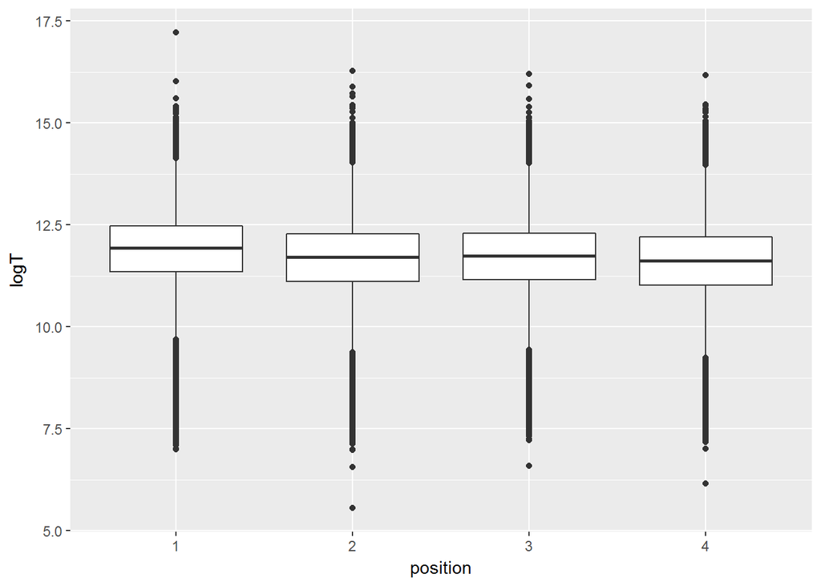

```r
ggplot(qTimeFinal, aes(position, logT)) + geom_boxplot()
```

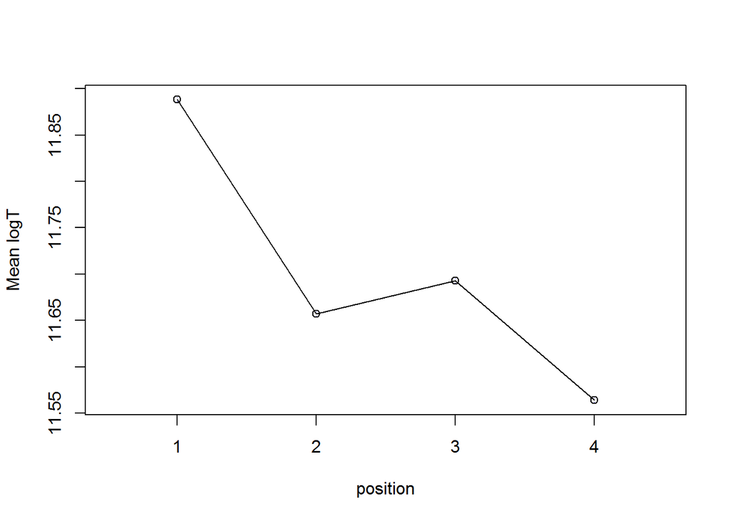

```r
gplots::plotmeans(qTimeFinal$logT ~ factor(qTimeFinal$position), connect=TRUE, xlab="position", ylab="Mean logT", n.label=FALSE)
```

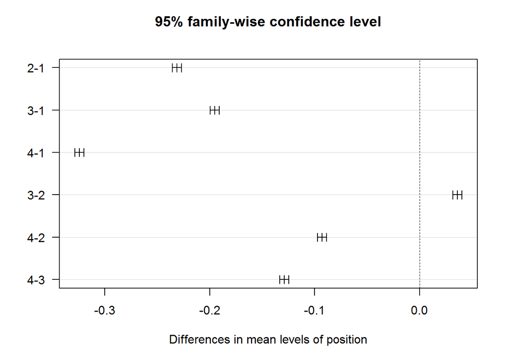

[output not shown]

```r
plot(TukeyHSD(aov(logT ~ position, data=qTimeFinal)), las=1)
```

Czas rozwiązania zadania znajdującego się na pierwszej pozycji jest największy. Wynika to zapewne z faktu, że uczniowie potrzebują czasu, by zapoznać się ze sposobem, w jaki wypełnia się w teście zadania. Najmniejszy średni czas rozwiązywania zadania na ostatniej pozycji może wynikać z faktu, że uczniowie znajdowali się pod presją czasu. Różnice w czasach nie wydają się jednak na tyle duże, by móc wyciągnąc z nich interesujące wnioski (chociaż test HSD Tukey’a sugeruje istotność różnic pomiędzy każdą z grup).

Podobną wizualizację przeprowadzamy dla poszczególnych ID zadań. Widzimy w szczególności, że generalnie istnieją różnice pomiędzy średnimi w poszczególnych zadanich.

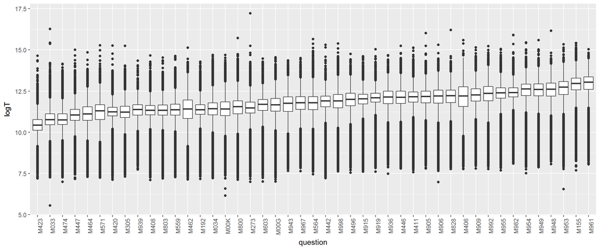

```r
ggplot(qTimeFinal, aes(x=reorder(question, logT, FUN=mean), y=logT)) + geom_boxplot() + theme(axis.text.x = element_text(angle = 90, hjust = 1)) + labs(x = "question")
```

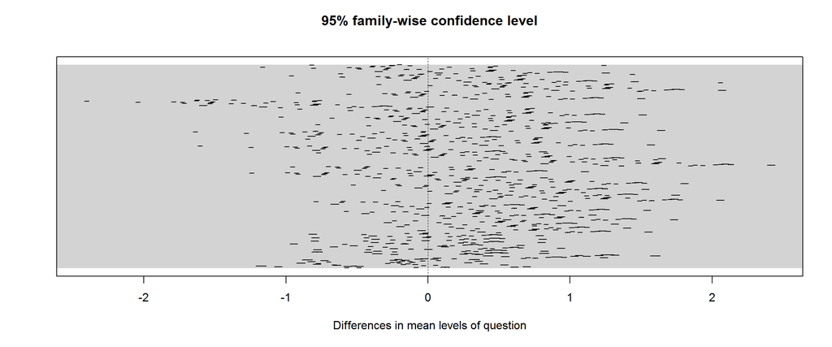

[output not shown]

```r
plot(TukeyHSD(aov(logT ~ question, data=qTimeFinal)), las=1,  yaxt="n")
```

Kolejny wykres przedstawia średni czas rozwiązania danego zadania w zależności od tego, na jakiej pozycji ono występuje.

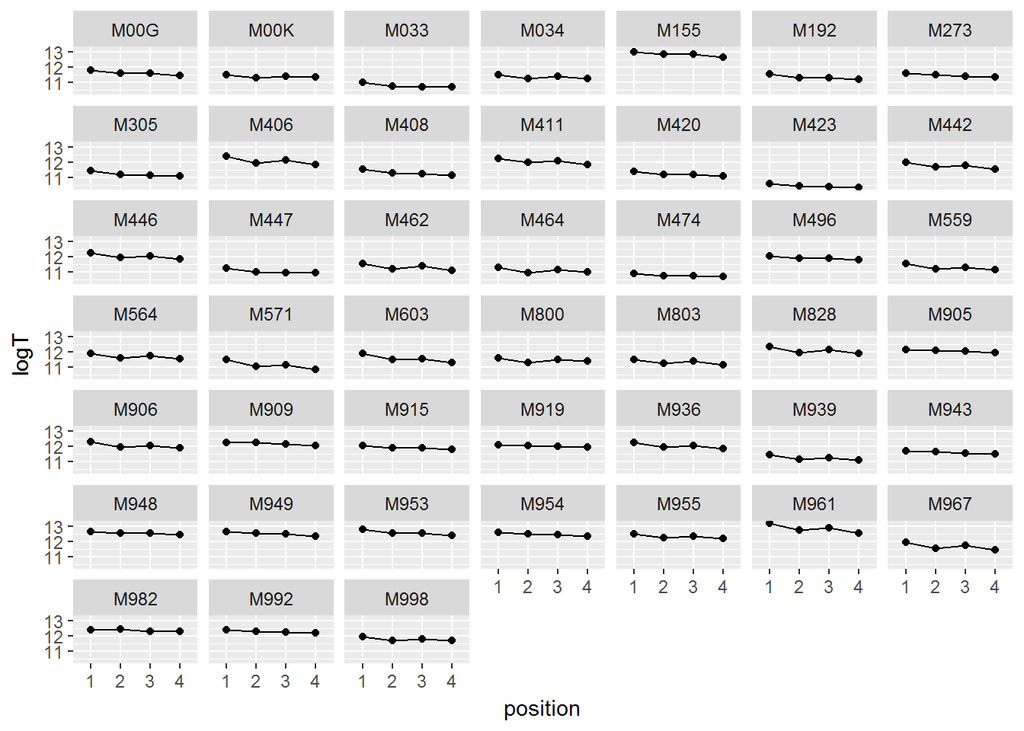

```r
qTimeFinalSum <- summarySE(qTimeFinal, measurevar="logT", groupvars=c("question","position")) #Liczy średnią oraz odchylenie standardowe dla zagnieżdżonych grup
ggplot(qTimeFinalSum, aes(position, logT, group=1)) + facet_wrap(~question) + geom_point() + geom_line()
```

## 2.2 Wybór modelu

W celu wyboru jednego z dwóch zaproponowanych modeli zacznijmy od wyznaczenia dla nich kryterium BIC:

```
## [1] "Kryterium BIC dla Modelu1 'logT ~ position + question' wynosi BIC =  4635688.27099481"
```

```
## [1] "Kryterium BIC dla Modelu1 'logT ~ position + position/question' wynosi BIC =  4622921.41520156"
```

[output not shown]

## 2.3 Wizualizacja modelu

Poniższe wykresy przedstawiają wartości parametrów regresji dla poszczególnych zmiennych w modelu

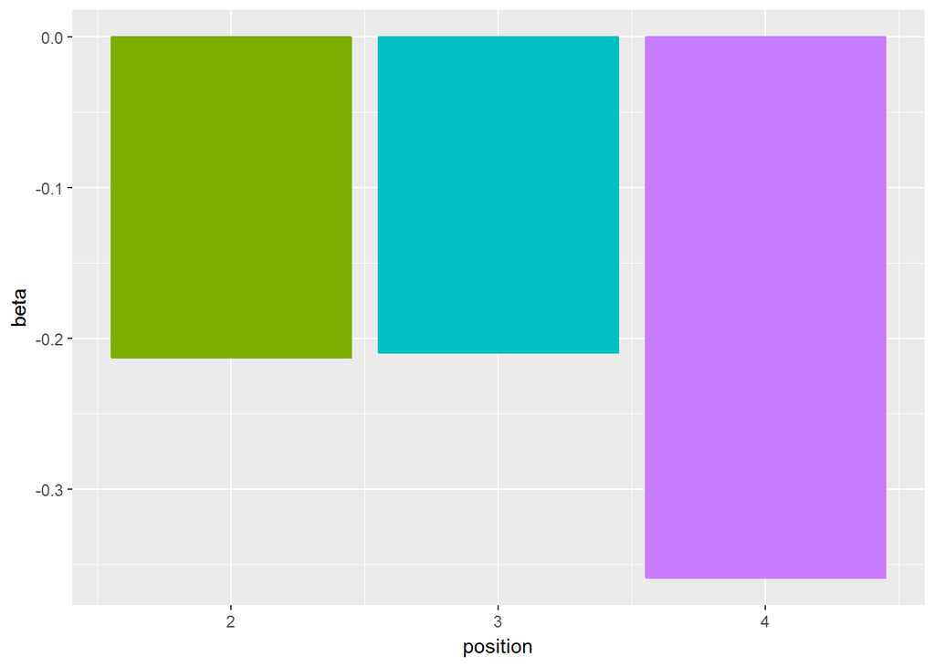

```r
gg_color_hax = c("#7CAE00", "#00BFC4", "#C77CFF")

coeff = model2$coefficients

coeff.names <- names(model2$coefficients) #Wyciaga nazwy bet
pos.df <- data.frame(beta = coeff[2:4], position = 2:4)

ggplot(pos.df, aes(position, beta)) + geom_bar(position = 'dodge', stat = 'identity', fill=gg_color_hax, color=gg_color_hax)
```

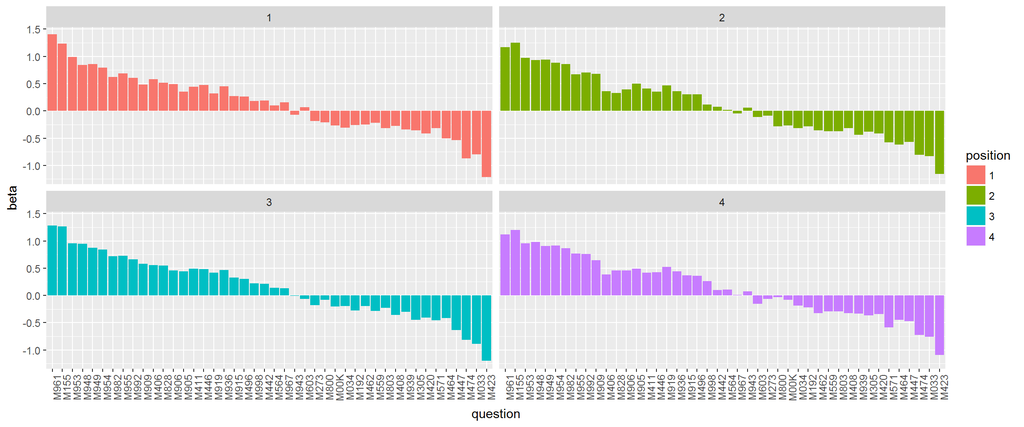

[output not shown]

```r
coeff.p <- unlist(lapply(X = coeff.names[5:180], FUN = function(x) substr(x, 9, 9)))
coeff.q <- unlist(lapply(X = coeff.names[5:180], FUN = function(x) substr(x, 19, 22)))
coeff.df <- data.frame(beta = unname(coeff[5:180]), position = coeff.p, question = coeff.q)

ggplot(coeff.df, aes(fill=position, x=reorder(question, -beta), y=beta)) + facet_wrap(~position) + geom_bar(position = 'dodge', stat = 'identity')+ theme(axis.text.x = element_text(angle = 90, hjust = 1)) + labs(x = 'question')
```

## 2.4 Diagnostyka modelu

Podstawowym założeniem, które jest niezbędne konstrukcji modelu jest normalny rozkład reszt. Poniższe wykresy mają na celu weryfikację, czy to założenie jest spełnione.

Wykres Q-Q pokazuje, że rozkład reszt w znaczącym stopniu odbiega od normalnego w prawym i lewym ogonie, co świadczy o kurtozie większej niż w rozkładzie normalnym. Niemniej dopasowanie w środkowej części jest dobre.

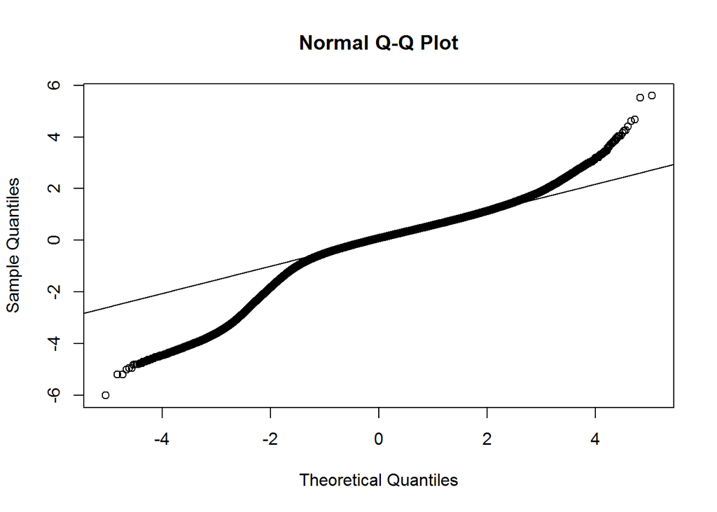

```r
qqnorm(model2$res)
qqline(model2$res)
```

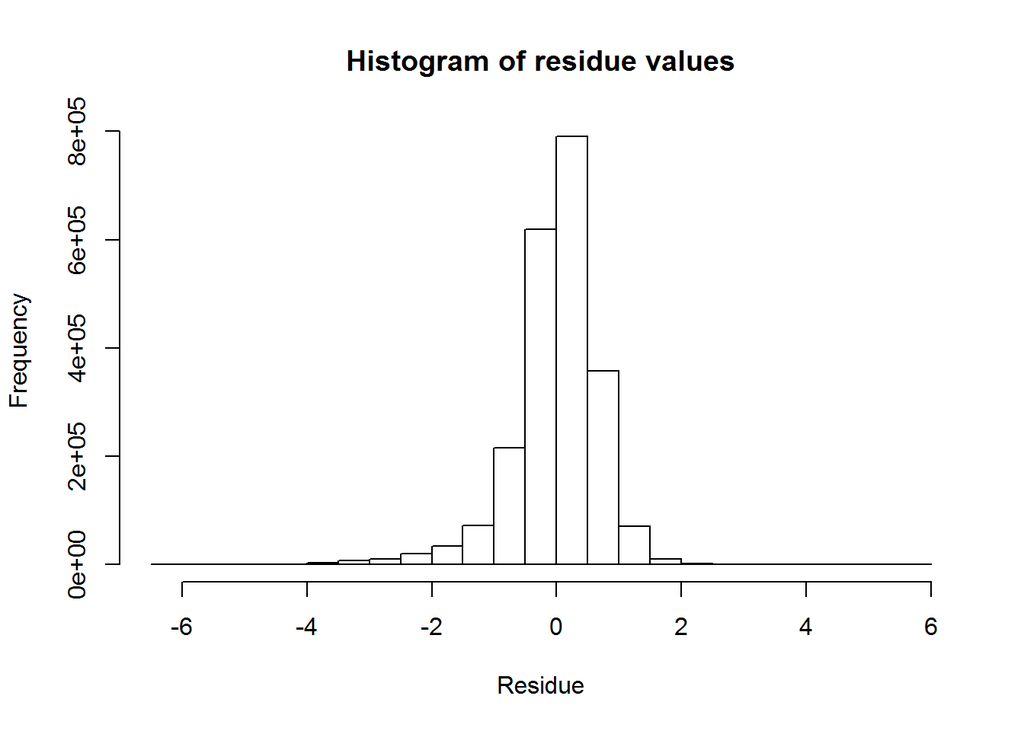

```r
hist(model2$res, main="Histogram of residue values", xlab="Residue")
```

Model nie przechodzi testu heteroskedastyczności reszt Breuscha-Pagana:

```r
lmtest::bptest(model2)
```

```
##
##  studentized Breusch-Pagan test
##
## data:  model2
## BP = 35349, df = 179, p-value < 2.2e-16
```

[output not shown]